# Tech Layoffs: Descriptive Statistics & Geographical Analysis

**Data source:** layoffs.fyi (PDF extracted and cleaned)  
**Period:** March 2020 – November 2025  
**Observations:** 4,207 layoff events across 67 countries  
**Total employees laid off** (where reported): **791,999**

## 1. Summary Statistics

Panel A: Continuous Variables

|  | N | Mean | Std | Min | P25 | Median | P75 | Max |
| --- | --- | --- | --- | --- | --- | --- | --- | --- |
| # Laid Off | 2747 | 288.3 | 1,004.0 | 3.0 | 40.0 | 88.0 | 200.0 | 22,000.0 |
| % | 2661 | 29.4 | 30.3 | 0.0 | 10.0 | 18.0 | 33.0 | 100.0 |
| $ Raised (mm) | 3737 | 828.4 | 4,581.6 | 0.0 | 52.0 | 169.0 | 479.0 | 121,900.0 |

Panel B: Layoffs by Year

| Year | Events | Total_Laid_Off | Avg_Laid_Off | Median_Laid_Off | Companies | Countries | Industries |
| --- | --- | --- | --- | --- | --- | --- | --- |
| 2020 | 635 | 80,998 | 171 | 60 | 598 | 30 | 27 |
| 2021 | 44 | 15,823 | 510 | 120 | 43 | 7 | 18 |
| 2022 | 1,230 | 165,269 | 201 | 80 | 1,064 | 51 | 28 |
| 2023 | 1,384 | 264,165 | 313 | 100 | 1,191 | 42 | 30 |
| 2024 | 632 | 152,922 | 394 | 100 | 551 | 34 | 30 |
| 2025 | 281 | 112,822 | 600 | 140 | 231 | 14 | 30 |

## 2. Layoffs Over Time

Monthly count of layoff events and total employees affected. The 2022–2023 period saw the largest waves, driven by post-pandemic corrections in the tech sector.

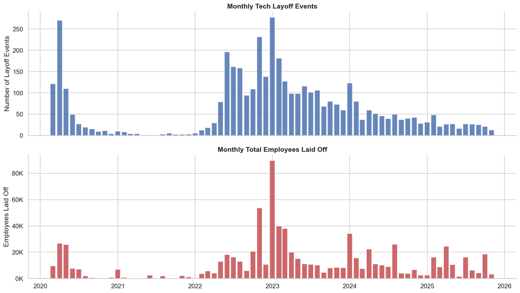

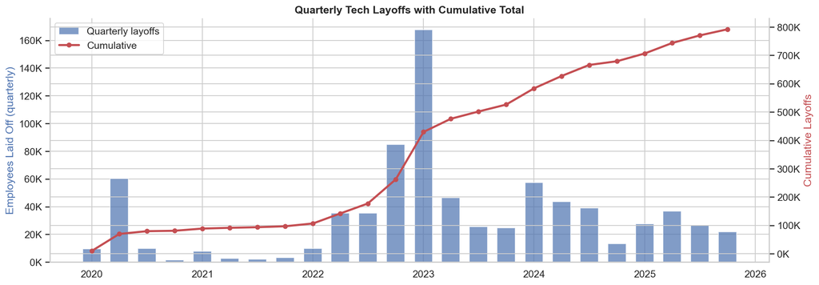

## 3. Geographical Distribution

The United States dominates the dataset, accounting for nearly two-thirds of all recorded layoff events. India, Canada, the UK, and Israel round out the top five.

[interactive chart not shown]

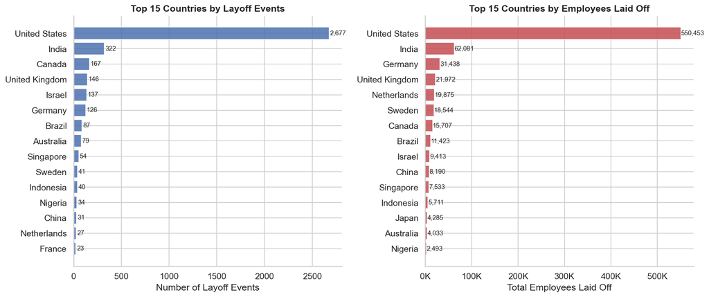

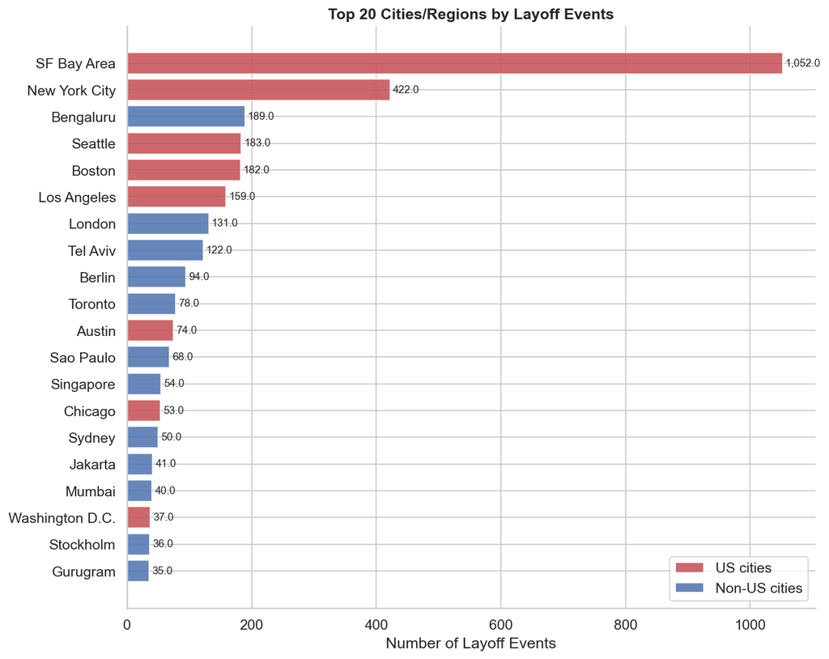

## 4. Geographic Evolution Over Time

The animated map below shows how layoffs spread geographically year by year. Use the slider to navigate across years.

[interactive chart not shown]

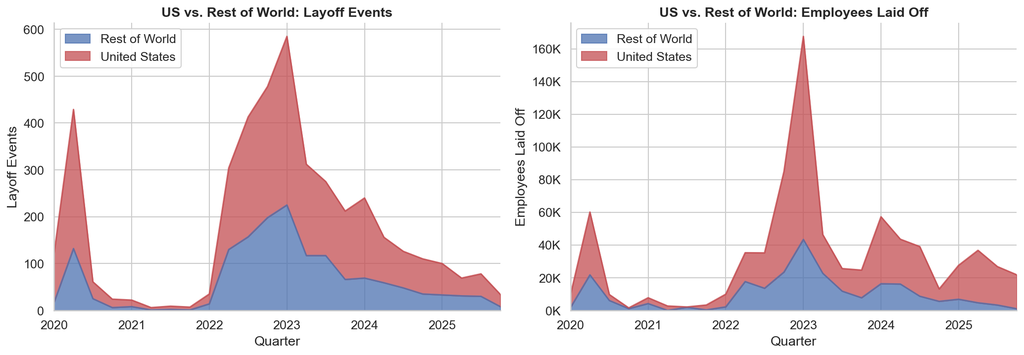

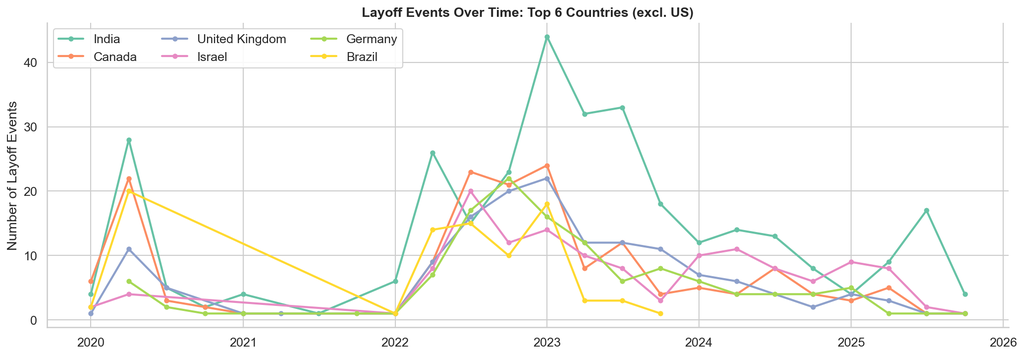

## 4b. US Deep Dive: State & City Heatmaps

Zooming into the United States, California dominates overwhelmingly — largely driven by the SF Bay Area — followed by New York and Washington state.

[interactive chart not shown]

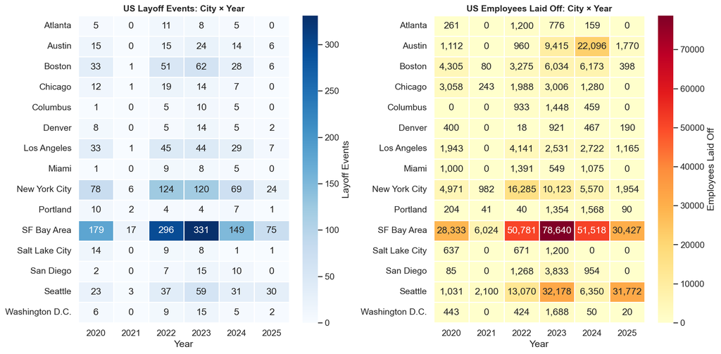

## 5. Industry Breakdown

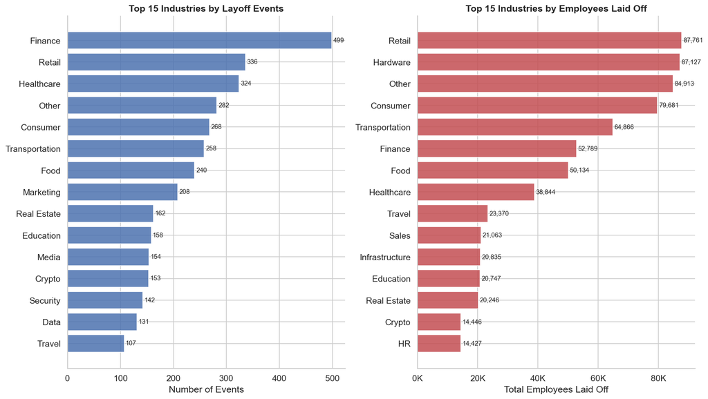

The heatmap below shows industry-level layoff totals by year. The 2023 peak is visible across nearly all sectors.

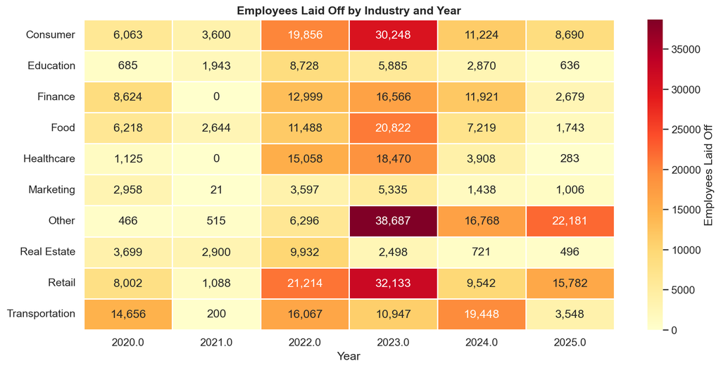

## 6. Company Stage & Funding

Post-IPO companies account for the largest share of layoff events and by far the largest average layoff size, reflecting the scale of publicly traded tech firms.

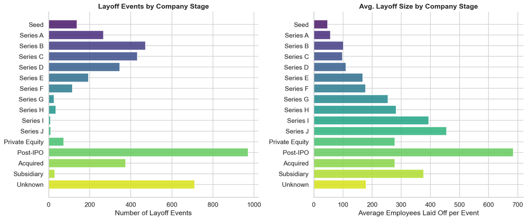

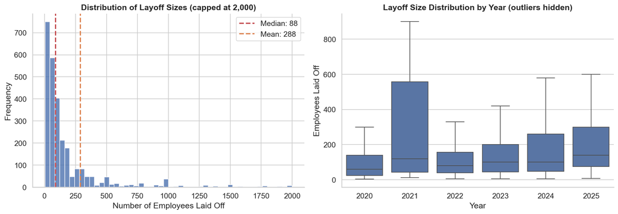

## 7. Largest Layoff Events

The table below lists the 25 largest individual layoff events in the dataset. Intel's 2025 restructuring tops the list with 22,000 employees.

Top 25 Largest Individual Layoff Events

| Rank | Company | Country | Industry | Date | # Laid Off | % | Stage |
| --- | --- | --- | --- | --- | --- | --- | --- |
| 1 | Intel | United States | Hardware | 2025-04-23 | 22,000 | 20.0 | Post-IPO |
| 2 | Intel | United States | Hardware | 2024-08-01 | 15,000 | 15.0 | Post-IPO |
| 3 | Amazon | United States | Retail | 2025-10-27 | 14,000 | 1.0 | Post-IPO |
| 4 | Tesla | United States | Transportation | 2024-04-15 | 14,000 | 10.0 | Post-IPO |
| 5 | Google | United States | Consumer | 2023-01-20 | 12,000 | 6.0 | Post-IPO |
| 6 | Meta | United States | Consumer | 2022-11-09 | 11,000 | 13.0 | Post-IPO |
| 7 | Meta | United States | Consumer | 2023-03-14 | 10,000 | NaN | Post-IPO |
| 8 | Microsoft | United States | Other | 2023-01-18 | 10,000 | 5.0 | Post-IPO |
| 9 | Amazon | United States | Retail | 2022-11-16 | 10,000 | 3.0 | Post-IPO |
| 10 | Microsoft | United States | Other | 2025-07-02 | 9,000 | 4.0 | Post-IPO |
| 11 | Amazon | United States | Retail | 2023-03-20 | 9,000 | NaN | Post-IPO |
| 12 | Ericsson | Sweden | Other | 2023-02-24 | 8,500 | 8.0 | Post-IPO |
| 13 | SAP | Germany | Other | 2024-01-23 | 8,000 | 7.0 | Post-IPO |
| 14 | Flink | Germany | Food | 2023-04-24 | 8,000 | 40.0 | Series B |
| 15 | Amazon | United States | Retail | 2023-01-04 | 8,000 | 2.0 | Post-IPO |
| 16 | Salesforce | United States | Sales | 2023-01-04 | 8,000 | 10.0 | Post-IPO |
| 17 | Dell | United States | Hardware | 2023-02-06 | 6,650 | 5.0 | Post-IPO |
| 18 | Microsoft | United States | Other | 2025-05-13 | 6,000 | 3.0 | Post-IPO |
| 19 | Dell | United States | Hardware | 2024-03-25 | 6,000 | 5.0 | Post-IPO |
| 20 | Philips | Netherlands | Healthcare | 2023-01-30 | 6,000 | 13.0 | Post-IPO |
| 21 | Cisco | United States | Infrastructure | 2024-08-09 | 5,600 | 7.0 | Post-IPO |
| 22 | Intel | United States | Hardware | 2025-07-11 | 5,000 | NaN | Post-IPO |
| 23 | Micron | United States | Hardware | 2023-01-01 | 4,800 | 10.0 | Post-IPO |
| 24 | Booking.com | Netherlands | Travel | 2020-07-30 | 4,375 | 25.0 | Acquired |
| 25 | Cisco | United States | Infrastructure | 2024-02-14 | 4,250 | 5.0 | Post-IPO |

Several companies have conducted multiple rounds of layoffs. The table below shows those with 4 or more rounds.

Companies with 4+ Rounds of Layoffs (129 total)

| Company | rounds | total_laid_off | country | industry |
| --- | --- | --- | --- | --- |
| Google | 17 | 13,697 | United States | Consumer |
| Amazon | 16 | 41,940 | United States | Retail |
| Microsoft | 16 | 30,055 | United States | Other |
| Salesforce | 12 | 16,525 | United States | Sales |
| Rivian | 11 | 2,110 | United States | Transportation |
| Intel | 11 | 43,115 | United States | Hardware |
| Oracle | 10 | 1,294 | United States | Other |
| Expedia | 8 | 1,600 | United States | Travel |
| Meta | 8 | 25,300 | United States | Consumer |
| TikTok | 8 | 1,610 | United Kingdom | Consumer |
| Redfin | 7 | 2,347 | United States | Real Estate |
| AppLovin | 7 | 790 | United States | Marketing |
| Spotify | 7 | 2,355 | Sweden | Media |
| Bytedance | 7 | 5,700 | Indonesia | Consumer |
| Unity | 7 | 3,199 | United States | Other |
| Better.com | 6 | 3,900 | United States | Real Estate |
| eBay | 6 | 1,740 | Israel | Retail |
| Loft | 6 | 1,289 | Brazil | Real Estate |
| F5 | 6 | 1,049 | United States | Security |
| Swiggy | 6 | 3,280 | India | Food |